# LIHAI experiment 1

Thomas Brochhagen

2023-12-21

# Categorical data

## Regression models

To get an idea of the estimated effect of different predictors on subjects’ judgments, I ran some regression models (logistic regression, logit-link). All models have a “random effect” for each stimulus and another one for each subject.You can think of this as an estimated offset from the mean for each item and subject, to allow for variation that may be due to differences across items/subjects. Models considered:

1. Intercept-only model
2. Intercept + `superglue_entailment` (TRUE/FALSE)
3. Intercept + `superglue_entailment` (TRUE/FALSE) + `referential_anchoring` (TRUE/FALSE) + `lexical_pragmatics` (TRUE/FALSE)
4. Intercept + `superglue_entailment` (TRUE/FALSE) + `lexical_pragmatics` (TRUE/FALSE)
5. Intercept + `superglue_entailment` (TRUE/FALSE) + `referential_anchoring` (TRUE/FALSE)
6. Intercept + `superglue_entailment` (TRUE/FALSE) + `either_referential_anchoring_or_lexical_pragmatics` (TRUE/FALSE)
7. Intercept + `referential_anchoring` (TRUE/FALSE) + `lexical_pragmatics` (TRUE/FALSE)

### Model estimates

The estimates are roughly in line with what I would expect. Likelihood of `TRUE` is higher for the cases in which the superglue entailment is labeled as `TRUE`, with a decrease if `lexical_pragmatics`/`referential_anchoring` are `TRUE`

#### Model 1

|  | Estimate | Est.Error | Q2.5 | Q97.5 |
| --- | --- | --- | --- | --- |
| Intercept | 0.0435027 | 0.2266416 | -0.4007103 | 0.4945184 |

#### Model 2

|  | Estimate | Est.Error | Q2.5 | Q97.5 |
| --- | --- | --- | --- | --- |
| Intercept | -1.804905 | 0.1768549 | -2.156915 | -1.465917 |
| superglue_entailmentTRUE | 3.663116 | 0.2492772 | 3.189598 | 4.176480 |

#### Model 3

|  | Estimate | Est.Error | Q2.5 | Q97.5 |
| --- | --- | --- | --- | --- |
| Intercept | -1.7716912 | 0.1691108 | -2.122985 | -1.4515465 |
| superglue_entailmentTRUE | 4.1874191 | 0.2767319 | 3.674535 | 4.7568110 |
| ref_anchoringTRUE | -0.7213371 | 0.4048921 | -1.524121 | 0.0671639 |
| lexical_pragmaticsTRUE | -1.0480670 | 0.3127420 | -1.680357 | -0.4293689 |

#### Model 4

|  | Estimate | Est.Error | Q2.5 | Q97.5 |
| --- | --- | --- | --- | --- |
| Intercept | -1.7893835 | 0.1737581 | -2.146937 | -1.4602976 |
| superglue_entailmentTRUE | 4.0609447 | 0.2772985 | 3.516616 | 4.6157564 |
| lexical_pragmaticsTRUE | -0.9940145 | 0.3271771 | -1.622512 | -0.3449706 |

#### Model 5

|  | Estimate | Est.Error | Q2.5 | Q97.5 |
| --- | --- | --- | --- | --- |
| Intercept | -1.7879450 | 0.1693600 | -2.123940 | -1.4615680 |
| superglue_entailmentTRUE | 3.7488151 | 0.2544391 | 3.257239 | 4.2590413 |
| ref_anchoringTRUE | -0.6347543 | 0.4276867 | -1.443734 | 0.2076435 |

#### Model 6

|  | Estimate | Est.Error | Q2.5 | Q97.5 |
| --- | --- | --- | --- | --- |
| Intercept | -1.7704599 | 0.1689386 | -2.103706 | -1.4443422 |
| superglue_entailmentTRUE | 4.1241937 | 0.2856696 | 3.579186 | 4.6906118 |
| eitherTRUE | -0.9445732 | 0.3071131 | -1.546905 | -0.3513861 |

#### Model 7

|  | Estimate | Est.Error | Q2.5 | Q97.5 |
| --- | --- | --- | --- | --- |
| Intercept | -0.3921803 | 0.2558344 | -0.8950248 | 0.1273684 |
| ref_anchoringTRUE | 0.9132718 | 0.7738697 | -0.6281960 | 2.4627106 |
| lexical_pragmaticsTRUE | 1.7671257 | 0.5366762 | 0.7567785 | 2.8535451 |

### Model ranking

Besides estimating effects, I also wanted to see if there is one of these models that is clearly better/worse than the others. The main reason for doing so is to check if some predictor(s) are doing most of the predictive heavy lifting / whether some predictors are not very useful. Model ranking is in terms of leave-one-out performance (expected log pointwise predictive density, i.e., how well out-of-sample data would be accounted for by each model). The best model is at the top and ranking is in terms of difference to the best model (elpd_diff). Taking into consideration that the ELPD differences are small (even moreso if factoring in the standard error of this difference, `se_diff`), the main thing we learn is that most models are similar. I’d say that only Model 1 and Model 7 are disprefered –but those also have fewer or less informative predictors so this is not very surprising.

|  | elpd_diff | se_diff | elpd_loo | se_elpd_loo | p_loo | se_p_loo | looic | se_looic |
| --- | --- | --- | --- | --- | --- | --- | --- | --- |
| m4 | 0.0000000 | 0.0000000 | -1056.375 | 29.47613 | 86.44595 | 3.428504 | 2112.751 | 58.95225 |
| m3 | -0.7410932 | 0.9802708 | -1057.116 | 29.58629 | 87.25625 | 3.461371 | 2114.233 | 59.17257 |
| m2 | -1.2393863 | 1.6358358 | -1057.615 | 29.45772 | 88.64675 | 3.546360 | 2115.229 | 58.91545 |
| m5 | -1.3094403 | 1.8387456 | -1057.685 | 29.51229 | 88.66649 | 3.531451 | 2115.369 | 59.02458 |
| m6 | -1.3584798 | 1.1412632 | -1057.734 | 29.51741 | 87.41638 | 3.471346 | 2115.468 | 59.03481 |
| m1 | -9.2072067 | 4.4647967 | -1065.582 | 29.49053 | 108.41030 | 4.886402 | 2131.165 | 58.98106 |
| m7 | -9.8963260 | 4.5408005 | -1066.272 | 29.62273 | 108.43206 | 4.909347 | 2132.543 | 59.24545 |

## Comparison of aggregation methods

Another thing we wondered about is to which extent the SuperGlue methodology (taking the mode of MTurkers as the gold standard) is hiding variation in judgements. Here are two visualizations that show that this is indeed the case. In both cases, we’re plotting the absolute value of the difference between the mode (superglue methodology) and the mean judgment for each stimulus. Values close to 0 indicate that there’s little to no difference in the aggregation method. Larger values are consequently of items where the mode and the mean differ more.

Visualization 1 plots the data using two boxplots. One for stimuli labeled as TRUE in superglue and the other for those labeled false. Visualization 2 further divides the data between cases where we labeled stimuli as being a case of either referential anchoring or lexical pragmatics vs. cases where neither label applied.

We see two main things:

1. Plot1: There is a lot of variation. There’s a mean difference of about 0.12 between the mode and the mean, and a few items go far beyond that. In this regard, there is no difference between TRUE or FALSE superglue entailments
2. Plot2: Items we had marked as either anchoring or pragmatics cases evince more variation than those that do not.

### Plot 1

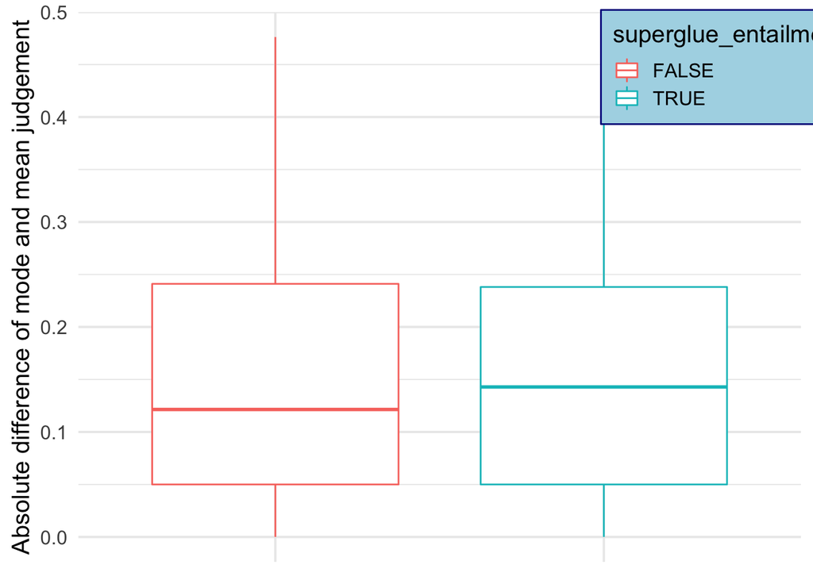

### Plot 2

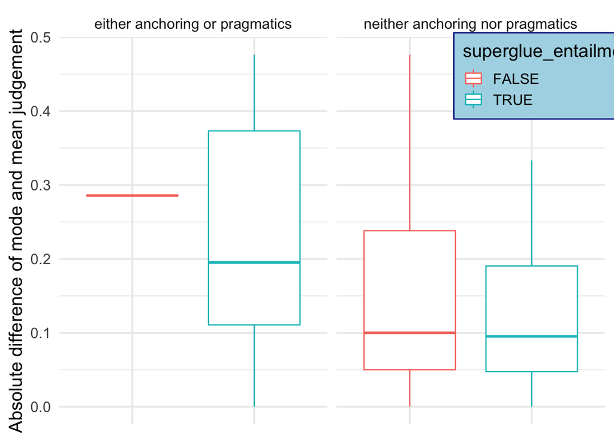

### Model 1

Here are the results of a Beta regression using an intercept-only to estimate the mean absolute difference of mode and mean judgments, together with 95% CIs (estimates are on logit-scale).

```
##           Estimate Est.Error      Q2.5     Q97.5
## Intercept -1.85845 0.1284315 -2.112769 -1.613578
```

### Model 2

Here are the results of a Beta regression using the “either” label to estimate the mean absolute difference of mode and mean judgments, together with 95% CIs (estimates are on logit-scale).

```
##              Estimate Est.Error        Q2.5     Q97.5
## Intercept  -2.0267923 0.1515949 -2.33678338 -1.740016
## eitherTRUE  0.6002005 0.2603835  0.09511016  1.110852
```

And here are the marginal effects of the “either” label on the mean absolute difference of mode and mean.

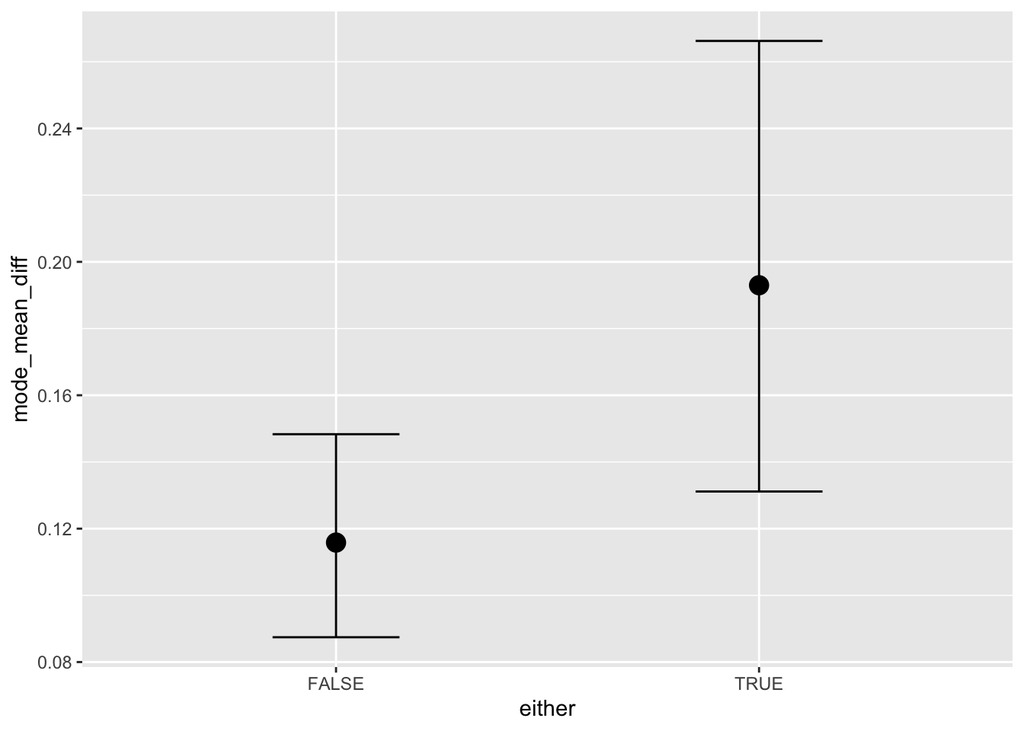